# spiking experiment

Note that this notebook uses older versions of the stringently filtered taxonomic datasets per run. These datasets have since been updated in June 2025, to remove any reads qith NA in the taxa info from superkingdom/domain to species.y. However, because I searched for Campylobacter below using the species.x column, the results will be the same using these older datasets as they would if I used the new datasets, because the species.x columns (generated from the blast results) never had NAS values in them, just the some of the subsequent taxonomizr columns added later (from superkingdom/domain to species.y). Therefore, the results below are still valid and true reflections of the observed C jejuni and C. jejuni M1 strain reads observed in spiked in C. jejuni samples used in this thesis.

```r
library(tidyverse)
library(stringr)
library("RColorBrewer")
library("ggplot2")
```

load in all the taxonomy results from each run

```r
load("merged_all_runs")
```

[figure not shown]

```r
genus_counts_all_runs2 <- merged_all_runs_all_samples %>%
  mutate(superkingdom2 = paste0(superkingdom, domain)) %>% #need to make a column with superkingdom info because we have either superkingdom or domain depending on the run and we need to have all this info in one column
                        filter(str_detect(superkingdom2, "Bacteria")) %>%
                      group_by(sample_name, barcode, run, genus) %>%
                       summarise(genus_count = n()) %>%
                         mutate(prop =prop.table(genus_count)) %>%
                         ungroup() %>%
                         arrange(desc(prop)) %>%
                         mutate(genus = factor(genus, levels = unique(genus)))
genus_counts_all_runs2 %>%
 # filter(prop > 0.002) %>% #filter to phyla that are present at least 0.2% in the data
  #mutate(phylum = if_else(prop < 0.002, "Other", phylum)) %>%#if the proporion of the phyla is less than 0.2%, then put all these phyla as 'other'\
  mutate(genus = if_else(prop < 0.2, "Other", genus)) %>% #AFTER FILTERING FOR UNIQUE TAXA ID, im now changing the other phyla proportion to 0.02, becuase a lot more will be represented on the graph if i left it at 0.002
  ggplot(aes(x=sample_name ,y=prop, fill=genus)) +
    geom_col() +
   # ylim(1,0) +
  ylim(0,1) + #26.4.24 flipping this back to 0 to 1 becuase its more interpretable now
    labs(x="Name", y="Proportion") +
        #title="Proportional distribution of bacterial phyla present per extraction method") +
     theme(text = element_text(size=12),
    axis.text.x = element_text(angle  = 90, vjust = 1.0, hjust = 1.0)) +
  #scale_fill_brewer(palette = "RdYlBu", direction = 1) +
scale_fill_manual(values=c("#dd3497","#ffffbf", "#313695", "#abd9e9","#fdae61", "#4575b4","#a50026","#addd8e","#bcbddc", "#fee090","#dd3497","#ffffbf", "#313695", "#abd9e9","#fdae61", "#4575b4","#a50026","#addd8e","#bcbddc", "#fee090","#dd3497","#ffffbf", "#313695", "#abd9e9","#fdae61", "#4575b4","#a50026","#addd8e","#bcbddc", "#fee090" ))
```

Downsampling all runs to 414794 reads and then getting campy counts

```r
species_counts_all_runs_downsample <- merged_all_runs_downsample %>%
                      group_by(sample_name, barcode, run, species.x) %>%
                       summarise(species.x_count = n()) %>%
                         mutate(prop =prop.table(species.x_count)) %>%
                         ungroup() %>%
                         arrange(desc(prop)) %>%
                          mutate(species.x = factor(species.x, levels = unique(species.x))) %>%
  filter(species.x == "Campylobacter jejuni")
```

the above results were inputted into an excel table (just the downsampling results, as this is all we are reporting on in the thesis). Here I am loading in this excel file so I can plot the read numbers by C. jejuni concentration

```r
downsample_results <- read.csv("spiked_campylobacter_downsample_counts.csv")

filtered_results <- downsample_results %>%
                    filter (concentration %in% c("10000000", "1000000", "100000", "10000"))
```

Plotting C. jejuni concentration on x axis and raed counts on y axis

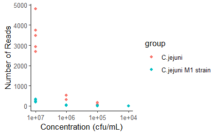

```r
#install.packages("ggforce")
library(ggforce)

 ggplot(filtered_results , aes(x = concentration, y = reads, color = group)) +
 geom_point() +

 scale_x_continuous(trans = trans_reverser('log10')) +

 labs(#title = "nUReads vs Concentration",
x = "Concentration (cfu/mL)",
y = "Number of Reads") +
  theme(axis.title.y = element_text(angle = 90)) +
theme_classic()
```

```r
NA
NA
```